# Séries chronologiques Projet 2022

Sujet 11

Matthias Lang

Janvier 30, 2022

## Synthèse du présent rapport

On a obtenu comme base de données les distances volées par une compagnie aérienne brittanique. Les données sont par mois pour la période 1963 - 1970. On vise à trouver un modèle pour décrire cette série temporaire et prévoir l’année 1971.

Pour y arriver, on les a premièrement transformées avec un $\log$, différenciées et de-saisonnalisées. Puis, on a cherché des bons modèles avec plusieures méthodes:

- une méthode itératif en interpretant les graphiques des ACF et PACF et puis en examinant si les résidus sont un bruit blanc et les coéfficients sont significatifs
- en entraînant quelques modèles avec les années 1963 - 1969 on a comparé les prévisions pour l’année 1970 avec les valeurs vraies
- la méthode de coins
- en utilisant la fonction `auto.arima`
- en comparant leurs AICs

On a trouvé plusieurs modèles validés. À l’aide de l’AIC et la méthode de coins on a finalement choisi un $\text{SARIMA}_{12}((1,1,2)(0,1,1))$, avec lequelle on a fait la prévision pour l’année 1971. On l’a également interprété.

## 1 - Les bases

Dans ce projet il faut effectuer une analyse des données reçues, et faire une prévision pour l’année 1971. Nous allons utiliser R avec les packages `tseries`, `astsa`,`forecast` et `lmtest`.

Premièrement, il suit une analyse rudimentaire des données et de leurs propriétés.

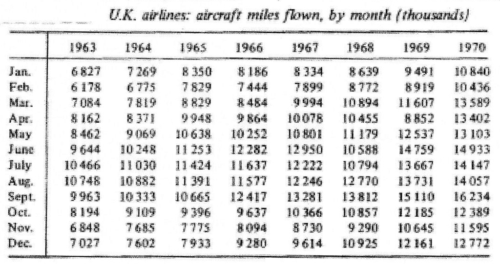

Les données sont affichées ci-dessous. C’est bien évident qu’il ne s’agit pas d’une séries stationnaire, car il y a une tendance. Dénommons les miles par mois avec la suite $(X_t)$.

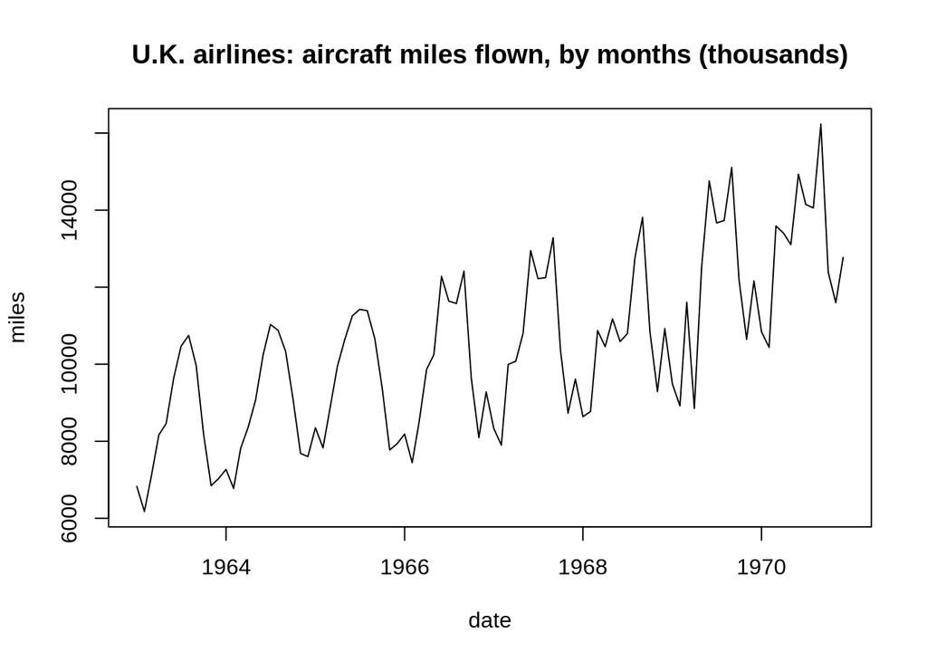

L’examen du graphique montre une tendance croissante, il paraît peut-être même une croissance exponentielle. Le dernier cas a lieu si la variance croit avec la tendance. C’est vraisemblable qu’il y a aussi une saisonnalité annuelle, c’est à dire de période 12 car les données sont mensuelles.

#### Transformation

Mais il semble aussi qu’il ait une croissance exponentielle. Cela ne surprend pas avec une échelle non-négative. Pour comparison: La variance de la première moitié est $2.7\times 10^{6}$, la seconde moitié $4.1\times 10^{6}$.

On répartit les données , dont on dispose de 96, dans 6 groupes. Leurs étendues en fonction de leur moyenne sont affichées ci-dessous pour les données originales et pour quelques transformations.

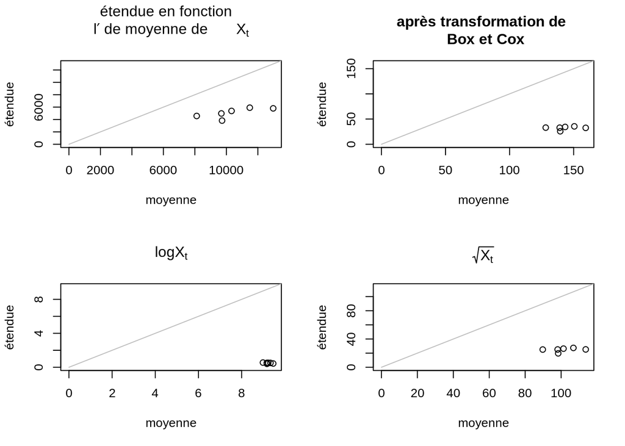

Les points de la série originale, en haut à la gauche, se trouvent un peu loin sous la diagonale, et ils sont d’un coup aussi déjà proche de l’axe. Le meilleur sera soit une transformation de Box et Cox, soit qu’on affirme qu’ils sont déjà stationnaire. On trouve pour le transformation de Box et Cox un $\lambda=$$0.454$, afin de faire une transformation en forme de $\frac{X_t^{\lambda} -1}{\lambda}$.

Pour comparaison, les données originales et les transformations sont plotées ci-dessous, standardisées.

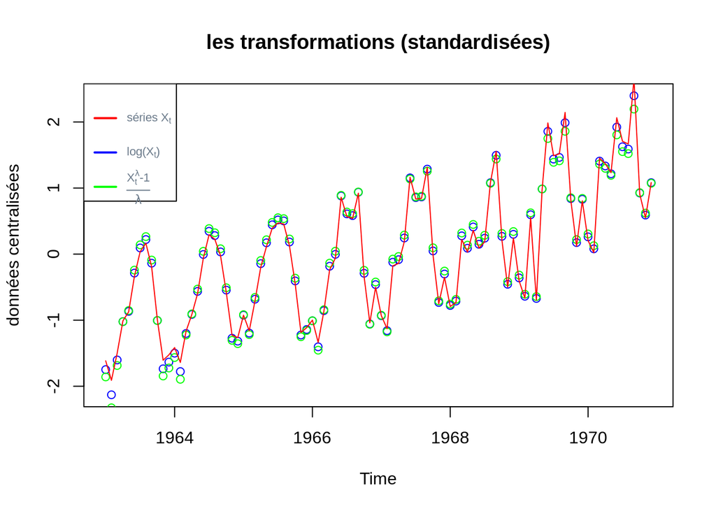

Mais comme vu, le logharithme népérien fait aussi en sorte que les variances soient égales, même si Box et Cox serait mieux. On va l’utiliser pour sa simplicité dans la suite, puisque on peut facilement re-transformer les prévisions avec $e^{X_t}$.

On voit que les données $\log(X_t)$ sont déja stationnaires:

```r
adf.test(log(donnees$miles), alternative = "stationary", k=0) #k=0 <=> standard dick-fuller test
```

```
##
##  Augmented Dickey-Fuller Test
##
## data:  log(donnees$miles)
## Dickey-Fuller = -4.5169, Lag order = 0, p-value = 0.01
## alternative hypothesis: stationary
```

Du coup, on va utiliser les données transformées comme affichées:

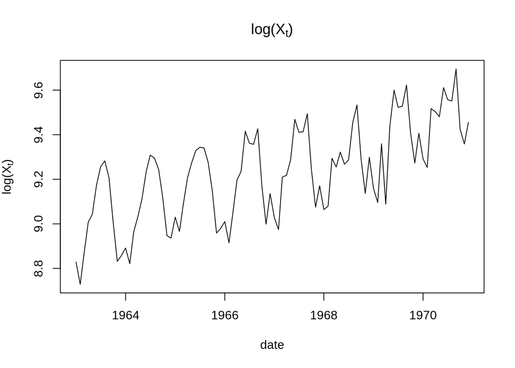

On a fait un Durbin-Watson Test afin de savoir si l’autocorrélation des erreurs estimées d’un modèle linéare `log(miles) ~ date` est égal à 0, qui est rejetée carrément avec une valeur p de $0$. Il y aura sûrement des autres assumptions blessées pour faire un GLM, par exemple l’égalité des variances et l’indépendence des valeurs et des erreurs. On va alors essayer de les modèliser et faire une prévision avec un modèle AR, MA, SAM, SAR, ARIMA ou SARIMA.

### La tendance

En gros, on a deux possibilités pour supprimer la tendance et faire en sorte que $\mathbb{E}[X_t] = 0$, soustraire une tendance ou différencier d’un ordre quelquonque.

##### traiter la tendance de manière additive

Peut-être c’est un modèl additif, dans lequel on modéliser plusieurs componants lesquelles, en somme, égalent la série d’origine :

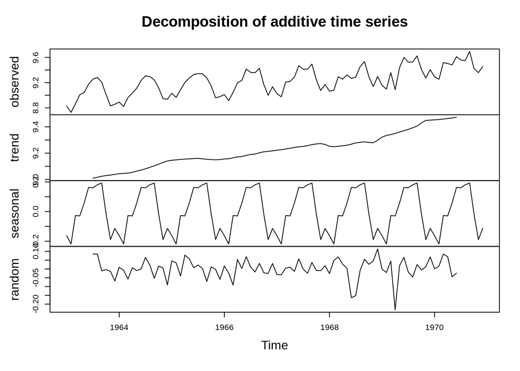

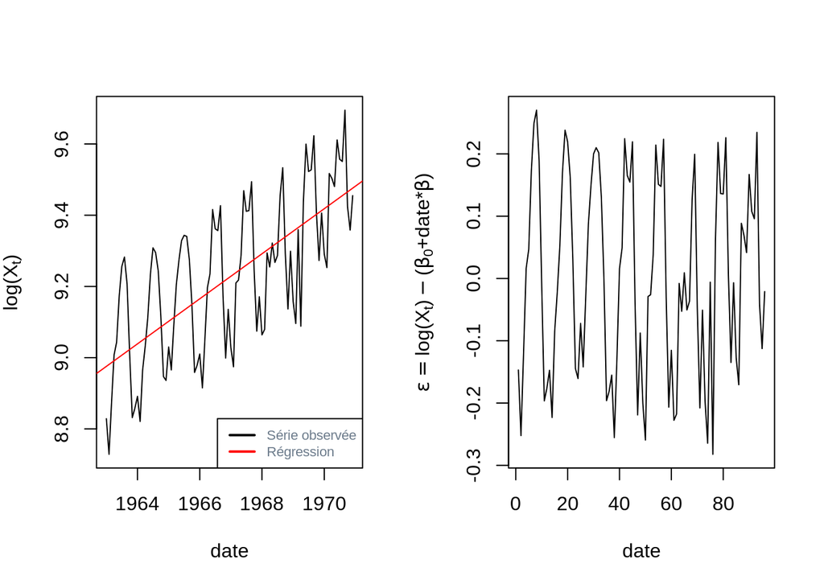

Ici un problème se présente:

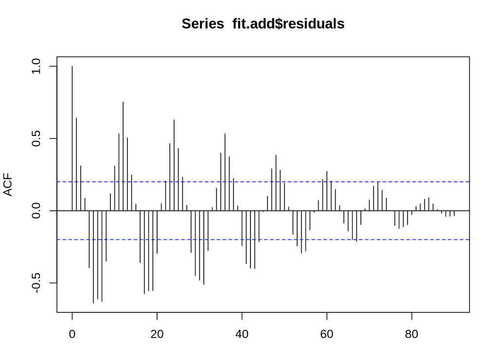

##### traiter la tendance en différenciant

On différencie une fois:
$$(1-B)\log(X_t)=log(X_t) - log(X_{t-1})$$

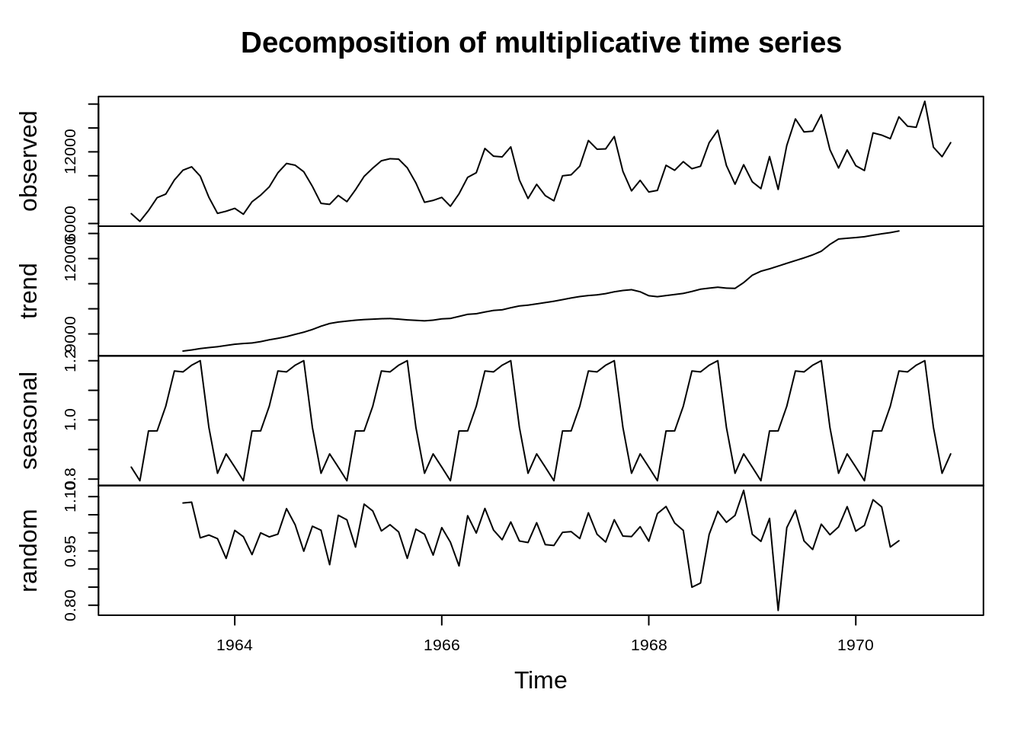

Je pense que traiter la séries de cette manière convient plus, car le decalage et la saisonnalité de la série croissent pendant le temps.

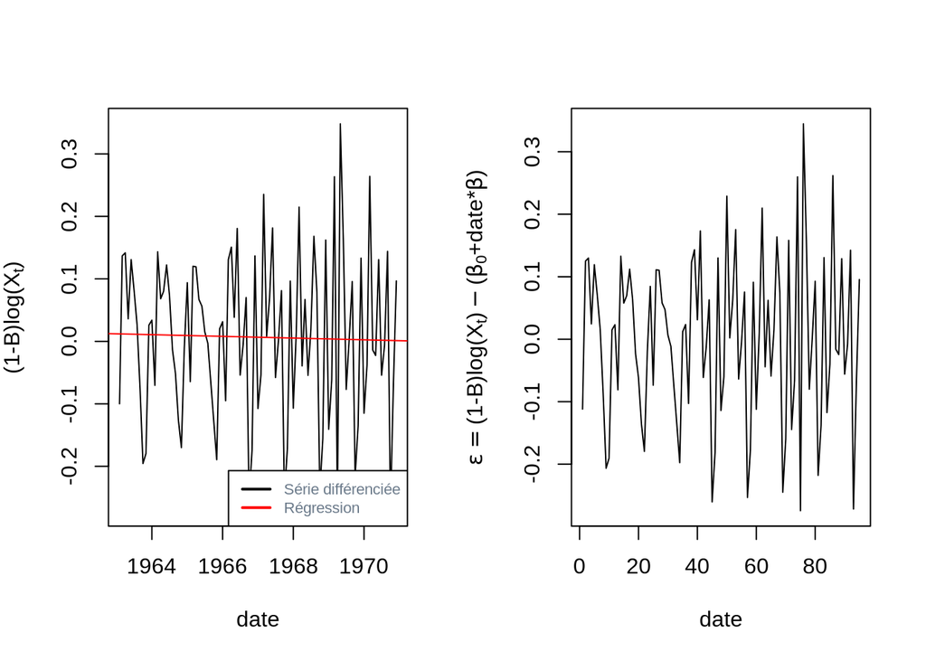

Il ne reste pas une tendence. Ci-dessous on voit que il n’y a ni une tendance ni une moyenne qui n’est pas zéro.

```r
summary(fit.mult)$coefficients
```

```
##                                         Estimate   Std. Error    t value
## (Intercept)                         2.469967e-03 2.232601e-02  0.1106319
## tail(donnees$date, length(mdiff1)) -3.760240e-06 1.620019e-05 -0.2321109
##                                     Pr(>|t|)
## (Intercept)                        0.9121467
## tail(donnees$date, length(mdiff1)) 0.8169619
```

Les coefficients d’une régression sur les données différencies est affichée. Il n’y a aucun coéfficient significatif, le coéfficient de l’ordonnée à l’origine est presque nul.

Laquelle méthode choisir ? Généralment différencier est mieux.

##### différencier deux fois?

Est-ce qu’il vaut différencier encore une fois ? On va comparer la variance de la série une fois différenciée, $\widehat{Var}((1-B)\log X_t = 0.017$ avec la série deux fois différencie, $\widehat{Var}((1-B)^2\log X_t = 0.036$ (pour comparaison: $\widehat{Var}(\log X_t = 0.046)$ ). Car on a déjà trouvé que la tendance a disparu, et on voit que différencier en supplémentaire fait augmenter la variance, il ne vaut pas encore différencier.

### Saisonnalité

On introduit une componente saisonnal dans le modèl proposé.

$$(1-B)(1-B^{12}) \log(X_t)$$
où $(1-B^{12}) \log(X_t) = log(X_t) - log(X_{12})$.

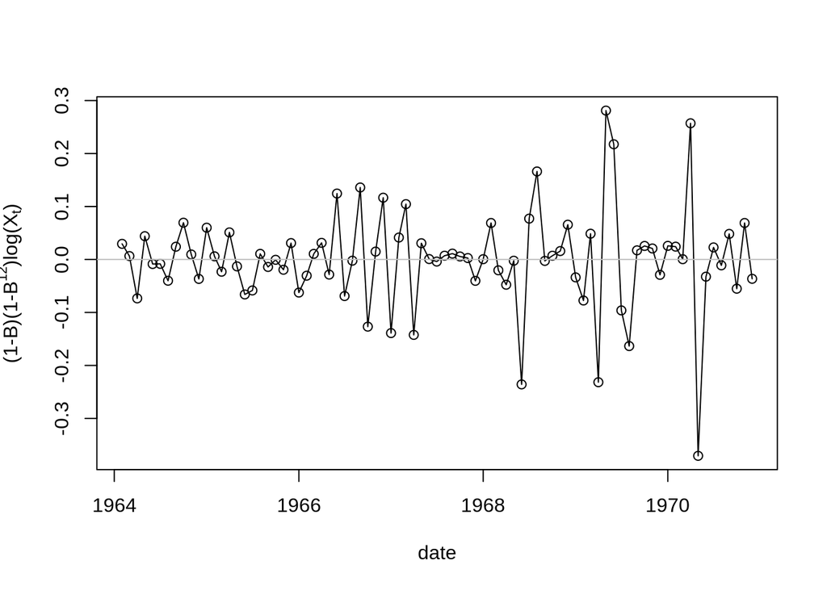

Est-ce qu’il vaut différencier encore une fois ? On va comparer la variance de la série une fois différenciée et de-saisonnalisé, $\widehat{Var}((1-B)(1-B^{12}\log X_t = 0.009$ avec la série deux fois de-saisonnalisé, $\widehat{Var}( (1-B)(1-B^{12})^2\log X_t ) = 0.024)$.

Comme encore plus différencier ne fait pas baisser la variance, et comme on verra que la série est déjà stationnaire, on ne différencie plus.

Pour tester si la série est stationnaire nous utilisons le Dickey-Fuller t-statistic test.

```
##
##  Augmented Dickey-Fuller Test
##
## data:  mdiff12diff1
## Dickey-Fuller = -5.9869, Lag order = 4, p-value = 0.01
## alternative hypothesis: stationary
```

On suppose donc que la série est stationnaire de 2nd ordre:

$\forall t \in \mathbb{Z}:~\mathbb{E}(X_t^2) < \infty,~ \mathbb{E}(X_t) = m$ et $\forall t \in \mathbb{Z}; \forall h \in \mathbb{Z}:~ cov(X_t, X_{t+h}) = \gamma(h)$

## 2 - Modéliser

Dans le suivant on va essayer de entraîner le bon modèle, bien sachant qu’il y plusieurs modèles qui peuvent apparaître significatifs. Après qu’on a transformé les données on a également déjà différencié, et donc en differenciant on a aussi déja trouver que $d=1$ et $D=1$.

On va toujours utiliser une modele de la forme ARIMA((p,d,q),(P,D,Q))[12]. 12, parce qu’on a des données mensuelles.

Il reste alors a trouver les bon nombre de p et P pour un modèle AR, q et Q pour un modèle MA, ou même les deux (on considère que les AR et MA sont un cas particulier d’un ARIMA avec respectivement $q=0$ et $p=0$).

Pour le moment on ne va pas les interpréter, mais on va seulement chercher un modèle qui a:

- des coéfficients significatifs
- une forme canonique ainsi que restent que des bruits blancs (Box-Jenkins-Test), c.a.d.
- des $\varepsilon_t$ non corrélés, avec variance constante et sans structure détérministe.

On n’incluit pas les modèles qui ne satisfont pas ces critères.

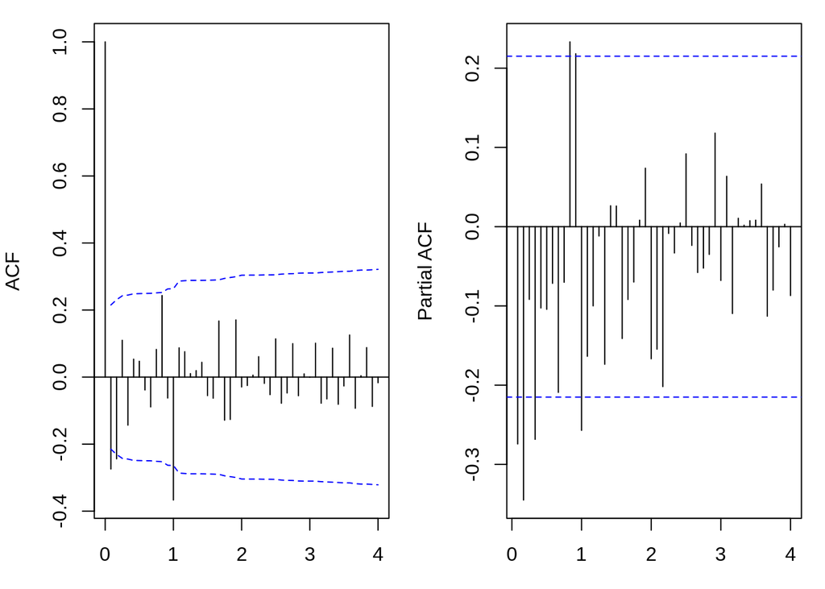

### Modèle 1

##### a) inférence sur les paramètres

Premierement on va regarder les paramètres saisonales. Il suffit de regarder les bâtons de decalage 12, 24, 36 …(Ils correspondent à lag 1.0, 2.0 et 3.0 dans le graphique). Sur le coup, c’est $\hat\rho(12)$ qui est significatif. De l’autre côté on a $\hat r(12)$ qui est significatif. Mais là on observe également des bâtons à lag 2.0, 3.0 et 4.0, bien qu’ils ne sont pas significatives. La chute de la partie saisonalle du PACF et le bâton à $\hat\rho(12)$ de l’ACF indiquent fortement P=0 et Q=1.

Enfin pour les paramètres p et q on va regarder les autres bâtons. Est-ce qu’on a un modèle AR ? Il y a une chute des $\hat\rho(h)$ vers 0, $\hat\rho(1)$ et $\hat\rho(2)$ sortent à peine. On pourrait supposer que c’est dû au hasard. On voit dans le diagramme PACF des bâtons sortir à h= 1, 2, 4, 10, 11 (et 12, celle ci a était pris en charge par Q=1) et après il n’y a plus de bâtons significatifs. Alors on aurait le modèle suivante, avec $\epsilon_t$ supposé b.b.:

$$\begin{aligned}
(1-\sum_1^{11} \phi_iB^i)
%-\phi_2B^2-\phi_3B^3-\phi_4B^4-\phi_5B^5-\phi_6B^6-\phi_7B^7-\phi_8B^8-\phi_9B^9-\phi_{10}B^{10}-\phi_{11}B^{11})
(1-B)(1-B^{12}) \log(X_t) =
= (1-\theta_{12}B^{12})\epsilon_t
\end{aligned}$$
Autrement dit, une $\text{SARIMA}_{12}[(p= 11,d= 1,q= 0),(P= 0,D= 1,Q= 1)]$. On va tenter ce modèle.

##### b) diagnoses

Après l’identification on peut l’estimer, et il faut faire des test si le modèle est significatif avec tous ces paramètres. Enfin il faut examiner les residues.

```
##
## Call:
## arima(x = log(miles), order = c(11, 1, 0), seasonal = list(order = c(0, 1, 1),
##     perdiod = 12))
##
## Coefficients:
##           ar1      ar2      ar3      ar4      ar5      ar6      ar7
##       -0.5702  -0.4431  -0.1962  -0.4836  -0.3501  -0.2216  -0.3206
## s.e.   0.1106   0.1296   0.1371   0.1366   0.1563   0.1539   0.1720
##           ar8      ar9    ar10     ar11     sma1
##       -0.4170  -0.1106  0.0480  -0.0877  -0.8211
## s.e.   0.1883   0.1672  0.1588   0.1405   0.2451
##
## sigma^2 estimated as 0.003561:  log likelihood = 109.89,  aic = -193.79
##
## Training set error measures:
##                        ME       RMSE        MAE         MPE      MAPE
## Training set 0.0003047737 0.05558483 0.03987001 0.001652222 0.4297304
##                   MASE         ACF1
## Training set 0.3742165 -0.009226124
```

```
##
## z test of coefficients:
##
##       Estimate Std. Error z value  Pr(>|z|)
## ar1  -0.570158   0.110618 -5.1543 2.546e-07 ***
## ar2  -0.443124   0.129581 -3.4197 0.0006270 ***
## ar3  -0.196178   0.137111 -1.4308 0.1524903
## ar4  -0.483556   0.136573 -3.5407 0.0003991 ***
## ar5  -0.350075   0.156329 -2.2393 0.0251333 *
## ar6  -0.221554   0.153947 -1.4392 0.1501066
## ar7  -0.320640   0.172027 -1.8639 0.0623360 .
## ar8  -0.417026   0.188305 -2.2146 0.0267851 *
## ar9  -0.110612   0.167245 -0.6614 0.5083703
## ar10  0.048050   0.158807  0.3026 0.7622198
## ar11 -0.087726   0.140543 -0.6242 0.5325021
## sma1 -0.821090   0.245140 -3.3495 0.0008096 ***
## ---
## Signif. codes:  0 '***' 0.001 '**' 0.01 '*' 0.05 '.' 0.1 ' ' 1
```

On voit que beaucoup de $\phi_i$ ne sont pas significatives. Avant qu’on examine les residues, le plus pratique reste de supprimer quelques paramètres.

### Modèle 2

Il n’y a aucune repère qu’il faut un modèl multiplicatif (des bâtons qui sortent encadré par des bâtons de signe inversée).

On supprime alors le paramètres pour lesquelles on a pas observé des $r(h)$ qui sortent de leur intervalle de confiance. On voit dans le diagramme PACF des bâtons sortir à h= 1, 2, 4, 10, 11 (et 12, celle ci a était pris en charge par Q=1) et après il n’y a plus de bâtons significatifs. Alors on aurait le modèle suivante, avec $\epsilon_t$ supposé b.b.:

$$(1-\phi_1B-\phi_2B^2-\phi_4B^4-\phi_{10}B^{10}-\phi_{11}B^{11}) (1-B)(1-B^{12}) \log(X_t) = (1-\theta_{12}B^{12})\epsilon_t$$

autrement dit $\text{SARIMA}_{12}[(p= 11,d= 1,q= 0),(P= 0,D= 1,Q= 1)]$ parcimonieux.

```
##
## Call:
## arima(x = log(miles), order = c(11, 1, 0), seasonal = list(order = c(0, 1, 1),
##     perdiod = 12), transform.pars = FALSE, fixed = c(NA, NA, 0, NA, 0, 0, 0,
##     0, 0, NA, NA, NA), method = "CSS")
##
## Coefficients:
##           ar1      ar2  ar3      ar4  ar5  ar6  ar7  ar8  ar9    ar10
##       -0.4969  -0.4400    0  -0.2621    0    0    0    0    0  0.1861
## s.e.   0.1031   0.1027    0   0.0979    0    0    0    0    0  0.1187
##         ar11     sma1
##       0.0005  -0.6331
## s.e.  0.1174   0.1171
##
## sigma^2 estimated as 0.004913:  part log likelihood = 102.84
##
## Training set error measures:
##                        ME      RMSE        MAE          MPE      MAPE
## Training set -0.000710721 0.0606993 0.04029594 -0.009323776 0.4328803
##                   MASE        ACF1
## Training set 0.3782143 -0.05659439
```

```
##
## z test of coefficients:
##
##         Estimate  Std. Error z value  Pr(>|z|)
## ar1  -0.49690916  0.10310622 -4.8194 1.440e-06 ***
## ar2  -0.44002135  0.10272521 -4.2835 1.840e-05 ***
## ar4  -0.26207118  0.09793968 -2.6758  0.007454 **
## ar10  0.18612240  0.11874020  1.5675  0.117004
## ar11  0.00045811  0.11744907  0.0039  0.996888
## sma1 -0.63306722  0.11713937 -5.4044 6.503e-08 ***
## ---
## Signif. codes:  0 '***' 0.001 '**' 0.01 '*' 0.05 '.' 0.1 ' ' 1
```

#### Modèle 21

On modélise sans les coefficients qui ne sont pas significatifs, qui vas nous donner un autre modèle:

```
##
## z test of coefficients:
##
##       Estimate Std. Error z value  Pr(>|z|)
## ar1  -0.439221   0.100691 -4.3621 1.288e-05 ***
## ar2  -0.428219   0.099273 -4.3135 1.607e-05 ***
## ar4  -0.224234   0.097181 -2.3074   0.02103 *
## sma1 -0.639423   0.086591 -7.3844 1.531e-13 ***
## ---
## Signif. codes:  0 '***' 0.001 '**' 0.01 '*' 0.05 '.' 0.1 ' ' 1
```

On a un modèle significatif. Idéalement il faut examiner les résidus, mais pour être bref on ne vais pas le faire. On va le faire pour un seul modèle à la fin, bien sachant qu’il faudrait le faire chaque fois pour déterminer s’il fallait encore ajouter des paramètres.

### Modèle 3

En regardant les corrélations des résidues du model21 on remarque qu’il y a des corrélations partials des $\varepsilon$. On ne va pas suivre les modèles AR pur.

Pour le modèle 2.1 on a eu un graphique pour les autocorrélations suivants. Il y a aucune indice qu’il s’agit d’un modèle multiplicatif.

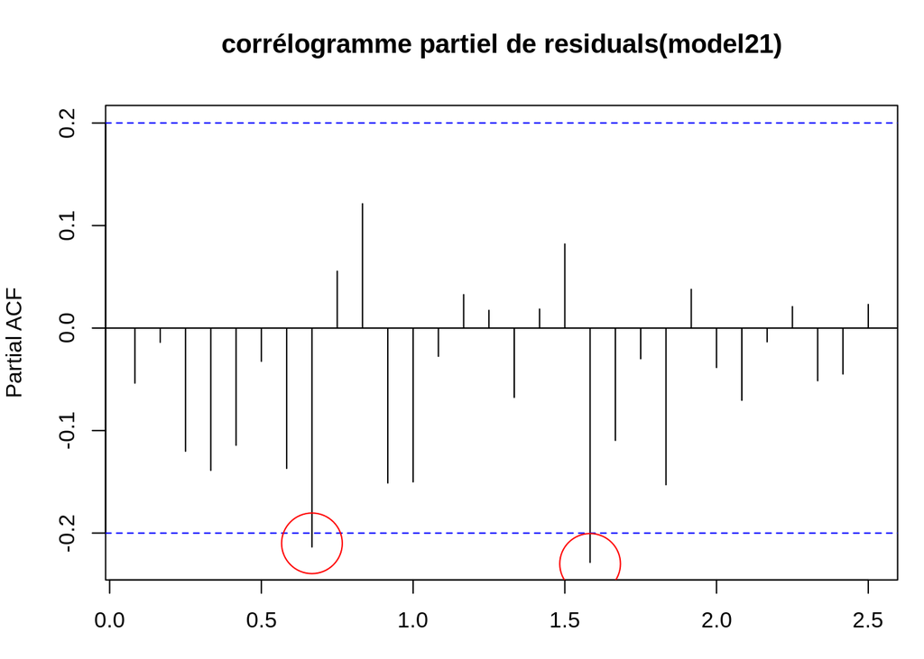

On regarde encore une fois les graphiques de ACF et PACF de la série transformée:

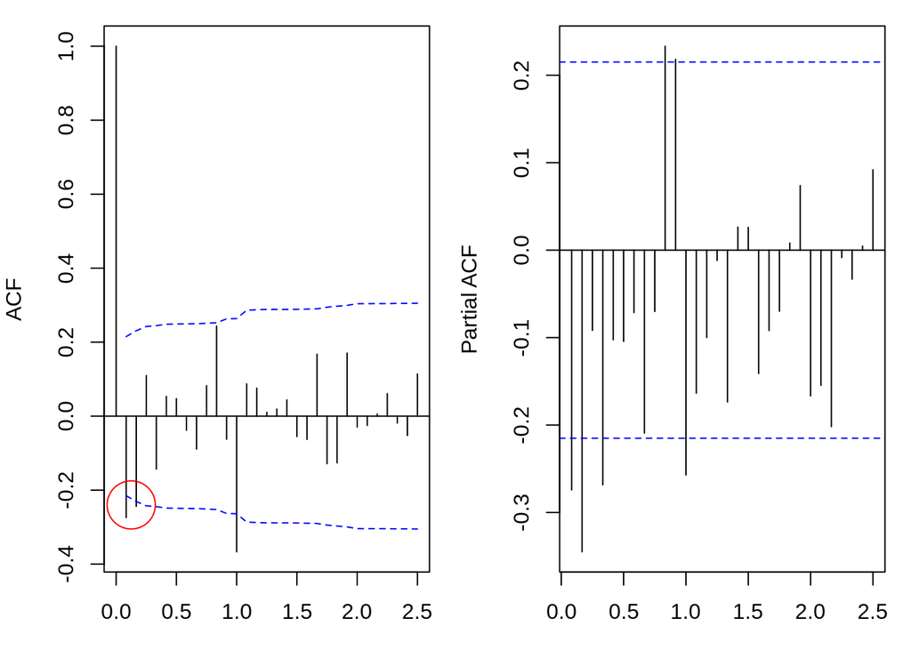

En ce qui concerne les auto-corrélations partielles, il y a égalements des fréquences significatives pour un décalage de 1,2,4, 10, 11 et 12 mois, et cela ne se abbaisse pas avec un lag plus grand semble-t-il. Cela indique qu’il faut un modèle MA !

Ce n’est pas évident si $\hat\rho(2)$ est significatif. Donc on va tester:

Dans le graphique “ACF”, est-ce que $\rho(2)$ sort de l’intervalle de confiance ? Cela peut indiquer qu’il a encore une componente MA dans les erreurs. Pour répondre à cette question, on va faire le calcul.

Intervalle de Bartlett q= 2:
$$\begin{aligned}
\pm \frac{1.96}{\sqrt{N-1-12}} (1 + 2\hat{\rho}^2(1) + 2\hat{\rho}^2(2) )^{0.5} = \\
\pm \frac{1.96}{\sqrt{96-1-12}}(1 + 2*0.0729 + 2*0.0576 `)^{0.5} = \\
\pm 0.244 > \rho(2) = -0.24
\end{aligned}$$

SARIMA(4,1,2)(0,1,1)[12] :

$$\begin{aligned}
(1-\phi_1B-\phi_2B^2-\phi_4B^4-\phi_{10}B^{10}-\phi_{11}B^{11}) (1-B)(1-B^{12}) \log(X_t) = \\
(1-\theta_1B-\theta_2B^2)(1-\theta_{12}B^{12})\epsilon_t
\end{aligned}$$

```
##
## Call:
## arima(x = log(miles), order = c(4, 1, 2), seasonal = list(order = c(0, 1, 1),
##     perdiod = 12), transform.pars = FALSE, fixed = c(NA, NA, 0, NA, NA, NA,
##     NA), method = "CSS")
##
## Coefficients:
##           ar1     ar2  ar3      ar4      ma1      ma2     sma1
##       -0.2749  0.0273    0  -0.1223  -0.2861  -0.5415  -0.6095
## s.e.   0.3921  0.2514    0   0.2322   0.3700   0.5029   0.0953
##
## sigma^2 estimated as 0.004636:  part log likelihood = 105.24
##
## Training set error measures:
##                       ME       RMSE        MAE       MPE      MAPE
## Training set 0.002937735 0.06176729 0.04333789 0.0294494 0.4663956
##                   MASE        ACF1
## Training set 0.4067658 -0.01961168
```

```
##
## z test of coefficients:
##
##       Estimate Std. Error z value  Pr(>|z|)
## ar1  -0.274919   0.392079 -0.7012    0.4832
## ar2   0.027290   0.251374  0.1086    0.9135
## ar4  -0.122323   0.232232 -0.5267    0.5984
## ma1  -0.286127   0.369986 -0.7733    0.4393
## ma2  -0.541528   0.502944 -1.0767    0.2816
## sma1 -0.609477   0.095273 -6.3971 1.583e-10 ***
## ---
## Signif. codes:  0 '***' 0.001 '**' 0.01 '*' 0.05 '.' 0.1 ' ' 1
```

### Modèle 4

Il faut enlever quelques parametres. On va essayer de estimer un modèle MA, c’est-à-dire on enlève les quatre paramètres AR. Ceci est encore plus parcimonieux que le modèle 3!

$$(1-B)(1-B^{12}) \log(X_t) =
(1-\theta_1B-\theta_2B^2)(1-\theta_{12}B^{12})\varepsilon_t$$

```
##
## Call:
## arima(x = log(miles), order = c(0, 1, 2), seasonal = list(order = c(0, 1, 1),
##     perdiod = 12))
##
## Coefficients:
##           ma1      ma2     sma1
##       -0.5795  -0.2795  -0.5206
## s.e.   0.1240   0.1394   0.0992
##
## sigma^2 estimated as 0.004624:  log likelihood = 102.71,  aic = -197.42
##
## Training set error measures:
##                        ME       RMSE        MAE          MPE      MAPE
## Training set 0.0003210825 0.06331477 0.04435319 0.0008956606 0.4781157
##                   MASE       ACF1
## Training set 0.4162952 -0.0291574
```

```
##
## z test of coefficients:
##
##       Estimate Std. Error z value  Pr(>|z|)
## ma1  -0.579535   0.123989 -4.6741 2.953e-06 ***
## ma2  -0.279518   0.139382 -2.0054   0.04492 *
## sma1 -0.520562   0.099211 -5.2470 1.546e-07 ***
## ---
## Signif. codes:  0 '***' 0.001 '**' 0.01 '*' 0.05 '.' 0.1 ' ' 1
```

Les paramètres sont significatifs. On va ensuite examiner les résidus.

Après differencier et modèliser il faut tester s’il reste qu’un bruit blanc. On peut utiliser un Box-Test. La p-valeur de Ljung-Box-Test des résidues : $0.7716948$. Donc on peut supposer un bruit blanc !

#### densité spectrale

Au lieu des ACF/PACF on pourrait examiner les fréquences des résidus estimés, ils contiennent la même information.

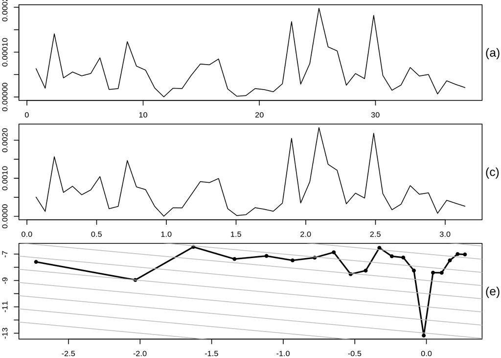

Pour les résidus il n’y a pas une courbe raide vers le zéro (voir (a), fréquence de Fourier $\omega_k = \frac{2\pi k}{n}$)). En outre, le log-périodogrammes des résidus tombe moins vite pour les résidus des données différenciées qu’implique des résidues stationnaires.

Comme $f(\omega)$ n’est pas connu, il fallait l’estimer, ce qu’on a fait ici par le spectogramm $I$. Si cette densité spectrale augmente aussi vite que $h(\omega ) = c\omega^{-1}$, on ne peux pas l’integrer, donc les $\epsilon_t$ ne serait pas stationnaire.

Pour une vite comparaison en (e) on a construit $\log(I(\omega))$ contre $\log(\omega)$ et le comparé avec la ligne en grisaille, avec tendance de $-1$. Tout de suite on voit, que la ligne et plus haut que les lignes qui descendent. C’est-à-dire, on suppose un bruit blanc !

## 3 - Choix du modèle

Le chapitre 2 était plutôt exploratif. Cette méthode itérative peux bien servir à trouver le bon modèle. On regarde les corrélations, on ajoute des paramètres, on teste les résidues et les paramètres.

Comme ça on a fini avec un bon modèle. On peux trouver et tester les modèles des autres manières aussi, qui seront présentées ensuite.

### La méthode de coins

On veut avoir un ARMA (ARIMA/SARIMA) minimal. On ne connait pas les vrais $\Delta$, mais on peut les estimer. On pourrait aussi tester s’ils soient significatifs, mais cela est très compliqué pour être démontrer ici.

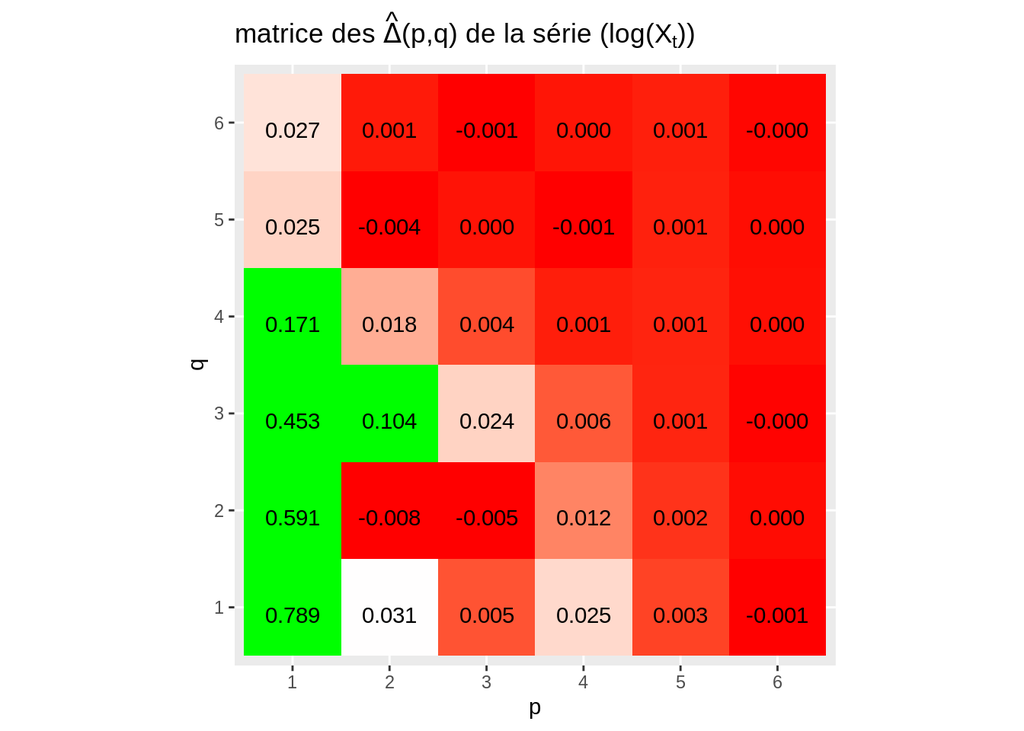

```r
minArma = function(series=log(miles), taille = 6){
  DELTA  = function(i,j, data=series)
  {
        rho = function(k) acf(data, plot="F")$acf[,1,1][abs(k)+1]
        D = matrix(nrow=j, ncol=j)

          for (m in 1:j)
          {
            for (n in 1:j)
            {
              D[m,n] = rho(i+m-n)
            }
          }
    return( det(D) )
  }

  minArma = matrix(nrow=taille, ncol=taille)

        for (r in 1:taille)
        {
          for (c in 1:taille)
          {
            minArma[r,c] = DELTA(r,c)
            minArma
          }
        }

  return(minArma)
}
```

On trouverait un ARMA(1,1) ou ARMA(1,3) au maximum. Pour trouver un ARIMA, on passe à la série différenciée.

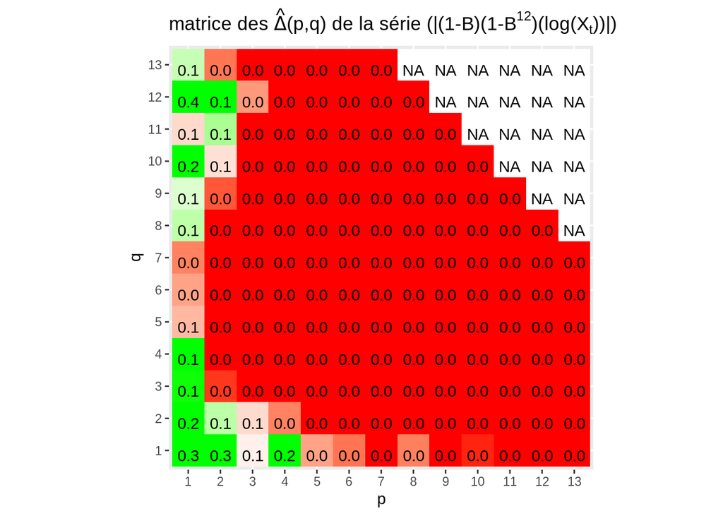

Cela nous donnerait un ARIMA(1,2). Pour un SARIMA((p,1,q),(P,1,Q))[12] on peut pas puiser les nombre d’estimateurs pour D et Q de ce graphique. Mais il semble comme s’il y a un saisonnalité pour Q.

#### Modèle 5

```
##
## Call:
## arima(x = log(miles), order = c(1, 1, 2), seasonal = list(order = c(0, 1, 1),
##     perdiod = 12))
##
## Coefficients:
##           ar1      ma1      ma2     sma1
##       -0.4919  -0.0857  -0.6350  -0.5402
## s.e.   0.2214   0.2009   0.1311   0.0986
##
## sigma^2 estimated as 0.004496:  log likelihood = 103.8,  aic = -197.59
```

Cela indique un modèle SARIMA((1,1,2)(0,1,1))[12]. C’est surprenant, parce qu’il y a aucune indice pour la partie AR dans les corrélations des résidus du modèle 4, qui est purement un SMA différencié.

```r
modele6 = arima(log(miles), order = c(1,1,2), fixed=c(NA,NA,0,NA),
                  seasonal=list(order = c(0,1,1), perdiod=12))
coeftest(modele6)
```

```
##
## z test of coefficients:
##
##       Estimate Std. Error  z value  Pr(>|z|)
## ar1   0.290606   0.140108   2.0742   0.03806 *
## ma1  -0.912366   0.086040 -10.6040 < 2.2e-16 ***
## sma1 -0.518839   0.099675  -5.2053 1.937e-07 ***
## ---
## Signif. codes:  0 '***' 0.001 '**' 0.01 '*' 0.05 '.' 0.1 ' ' 1
```

Le Ljung-Box-Test donne le p-valeur 0.9363942. On verra quand même que ce modèle-là n’est pas meilleur que celle-ci avec les deux paramètres.

### Base de test

Pour comparer la qualité des prévisions on peut utiliser le MSE (mean squared error), le plus faible le meilleur :

$\text{MSE} = \frac{1}{12}\sum_{t=Jan 1970}^{Dec 1970}(\hat{X_t} - X_t)^2$.

On estime les paramètres avec la base de donnée `miles.train` de largeur 84 (largeur original 96). En bleu les données la prévision sur `miles.test`, et la courbe noir sont les vraies valeurs :

[figure not shown]

MSE, c’est la diffèrence en carré entre les deux courbes.

[output not shown]

### AIC

Enfin on va se servir de l’AIC du modele complet.

Ci-dessous tous les modèles qu’on a trouvé sont comparés dans un tableau. Le plus faible l’AIC, le meilleur. Ils indiquent aussi si un modèle est parcimonieux. Ce critère repose donc sur un compromis entre la qualité de l’ajustement et la complexité du modèle, en pénalisant les modèles ayant un grand nombre de paramètres.

| variable | Model | AIC |
| --- | --- | --- |
| model1 | $\text{SARIMA}_{12}[(11, 1, 0),(0, 1, 1)]$ | $-193.7870011$ |
| model2 | $\text{SARIMA}_{12}[(11, 1, 0),(0, 1, 1)]$ parcimonieux | $-195.1098317$ |
| model21 | $\text{SARIMA}_{12}[(4, 1, 0),(0, 1, 1)]$ | $-195.5226641$ |
| modele3 | $\text{SARIMA}_{12}[(4, 1, 2),(0, 1, 1)]$ | $-194.7018397$ |
| modele4 | $\text{SARIMA}_{12}[(0, 1, 2),(0, 1, 1)]$ | $-197.4204989$ |
| modele5 | $\text{SARIMA}_{12}[(1, 1, 2),(0, 1, 1)]$ | $-197.5900468$ |
| modele6 | $\text{SARIMA}_{12}[(1, 1, 2),(0, 1, 1)]$ parcimonieux | $-196.9776791$ |

Ici c’est modele5 qui gagne !

### auto.arima

On peut également utiliser la fonction `auto.arima`, qui nous donne modele4. Cette fonction est basé sur l’AIC, donc elle n’a pas réussi à trouver notre modèle gagnant !

```r
auto.arima(log(miles), d=1, D=1)
```

```
## Series: log(miles)
## ARIMA(0,1,2)(0,1,1)[12]
##
## Coefficients:
##           ma1      ma2     sma1
##       -0.5795  -0.2795  -0.5206
## s.e.   0.1240   0.1394   0.0992
##
## sigma^2 = 0.004811:  log likelihood = 102.71
## AIC=-197.42   AICc=-196.91   BIC=-187.75
```

## 4 - Intérpretation du modèle choisi

On a donc choisi le modèle 5 suivant, un $\text{SARIMA}_{12}[(1, 1, 2),(0, 1, 1)]$.

$$(1-\phi_1)(1-B)(1-B^{12}) \log(X_t) =
(1-\theta_1B-\theta_2B^2)(1-\theta_{12}B^{12})\varepsilon_t$$

```
##
## Call:
## arima(x = log(miles), order = c(1, 1, 2), seasonal = list(order = c(0, 1, 1),
##     perdiod = 12))
##
## Coefficients:
##           ar1      ma1      ma2     sma1
##       -0.4919  -0.0857  -0.6350  -0.5402
## s.e.   0.2214   0.2009   0.1311   0.0986
##
## sigma^2 estimated as 0.004496:  log likelihood = 103.8,  aic = -197.59
##
## Training set error measures:
##                         ME       RMSE        MAE          MPE      MAPE
## Training set -6.163666e-05 0.06243339 0.04371648 -0.002717007 0.4710301
##                   MASE       ACF1
## Training set 0.4103192 0.00561131
```

```
##
## z test of coefficients:
##
##       Estimate Std. Error z value  Pr(>|z|)
## ar1  -0.491936   0.221421 -2.2217    0.0263 *
## ma1  -0.085699   0.200854 -0.4267    0.6696
## ma2  -0.634996   0.131136 -4.8423 1.284e-06 ***
## sma1 -0.540175   0.098558 -5.4808 4.234e-08 ***
## ---
## Signif. codes:  0 '***' 0.001 '**' 0.01 '*' 0.05 '.' 0.1 ' ' 1
```

### Les résidus

En regardant les résidus on observe qu’il semblent bien stationnaires. Apparemment ils sont indépendants, il y a que $\hat r(19)$ qui est significatif (le circle rouge). Je dis que c’est dû au hasard. On trouve que $E(\varepsilon_t\varepsilon_s)=0$, également on a déjà fait un teste portmanteau, on peux dire que c’est un bruit blanc.

Alors je constate qu’il ne faut pas ajouter encore des paramètres.

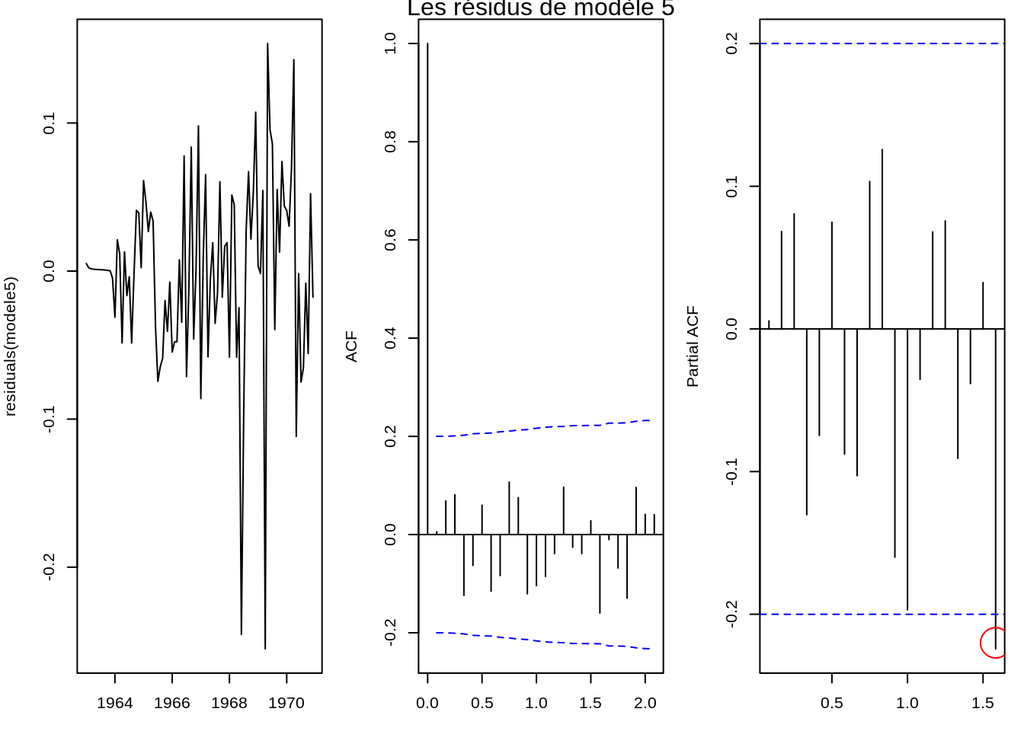

## 5 - Prévision pour l’année 1971

On effectue la prévision avec modele5, $\text{SARIMA}_{12}[(1, 1, 2),(0, 1, 1)]$.

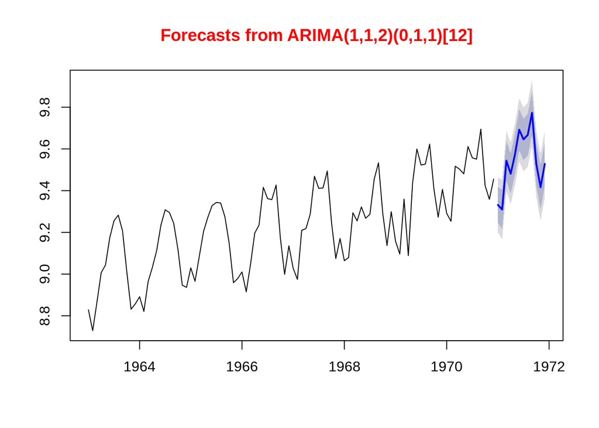

On re-transforme la prévision de $log(X_t)$ avec la fonction exponentielle de base $e$.

```
##           Jan      Feb      Mar      Apr      May      Jun      Jul
## 1971 11289.16 11042.74 13956.35 13107.88 14373.96 16190.44 15459.23
##           Aug      Sep      Oct      Nov      Dec
## 1971 15787.85 17557.17 13749.48 12285.79 13746.00
```